# Impacto del transporte entre la residencia del alumno y la universidad en su tiempo efectivo de trabajo y rendimiento académico

## Título corto: CommUtec

## P2 Segunda entrega

### **Sección:** 1.01

### **Profesor:** José Miguel Renom

| **Alumno** | **Código** | **Líder** |
| --- | --- | --- |
| Kevin Aubert | 201910019 |  |
| Andrea Chu | 201910124 |  |
| Juan Diego Chu | 201920069 | X |
| Oscar Gómez | 201910179 |  |
| Joaquín Ramírez | 201910277 |  |

### Introducción

El transporte urbano de Lima está en un estado deplorable debido a años de corrupción y manejo indebido de los recursos públicos. Uno de los principales problemas en una sociedad urbanizada es la movilización eficiente de los ciudadanos en el limitado espacio disponible. Según un estudio realizado por la empresa holandesa TomTom (2018), Lima es la tercera ciudad con más tráfico en el mundo. Esto significa que muchos limeños debemos invertir una gran cantidad de horas en transportarnos, debido a que el tráfico nos impide llegar a lugares más rápidamente.

Como estudiantes, consideramos que este tema es importante para nosotros y nuestros compañeros porque todos vivimos en Lima y debemos transportarnos a la universidad frecuentemente. Muchas de estas veces, nos topamos con el tráfico y largas horas de movilidad. Todo esto resulta en una carga físico-emocional que repercute en la vida diaria estudiantil, el cual no nos permite rendir a nuestro máximo potencial.

### Objetivo

El objetivo de esta investigación es analizar e informar acerca del impacto del viaje desde la residencia de un alumno hasta la universidad en su tiempo efectivo de trabajo y rendimiento académico. Con la información recogida, se desea responder a las preguntas planteadas y llegar a conclusiones representativas.

### Factibilidad

El transporte es una actividad en la que participan todos los alumnos con frecuencia diaria (antes de la actual pandemia). La pregunta es: **¿Influye el transporte entre la residencia del alumno a la universidad en su tiempo efectivo de trabajo y rendimiento académico?**

Nuestra actual **hipótesis** es la siguiente: **Sí influye, porque la experiencia de transportarse en Lima causa estrés y cansancio, e implica una cantidad significante de tiempo, lo cual limita nuestra productividad.** De esta manera, es importante entender el comportamiento del alumno analizando el plano mental, pues es el encargado de regir nuestras acciones, lo que tendrá impacto en nuestras notas. Es así que nuestro proyecto buscará comprender el impacto en la salud mental al igual que en el rendimiento académico, valorizando al estudiante en su totalidad.

### Población objetivo

Estudiantes universitarios

### Unidad muestral

Cualquier estudiante de UTEC cursando ciclo II en adelante

### Tipo de muestreo

Muestreo por conveniencia: fácil acceso a nuestra unidad muestral

### Obtención de datos

Al ser parte de la comunidad estudiantil de la misma universidad, tenemos acceso a los medios de comunicación pertinentes para realizar encuestas en línea. Es así que se elaborará una encuesta en SurveyMonkey o GoogleForms, y se distribuirá vía el grupo de Facebook de los alumnos. Si es necesario, solicitaremos ayuda del área de Bienestar Estudiantil, para que nos apoyen con la distribución de la encuesta. Nota: para poder responder las preguntas que toman los factores de opinión y el plano emocional, utilizaremos escalas psicométricas, como la escala de Likert.

### Planificación

Durante las primeras 4 semanas estuvimos planteando el tema y la viabilidad de ellos. Para la siguiente semana desarrollamos las preguntas e identificamos las variables concretas a estudiar. En las siguientes semanas se plantea elaborar la encuesta con la que se recogerán los datos y publicarla por Facebook. En las semanas posteriores se analizarán los datos con R, y se buscará responder las preguntas. Es vital resaltar que conforme recibamos *feedback* del profesor, mejoraremos las entregas del proyecto.

### Preguntas planteadas

| N° | Pregunta | Tipo de pregunta |
| --- | --- | --- |
| 1 | ¿Cuál es la edad de los encuestados? | Descriptiva |
| 2 | ¿Cuánto tiempo les demora a los estudiantes de UTEC llegar a la universidad desde su lugar de residencia? | Descriptiva |
| 3 | ¿Cómo califican los estudiantes la experiencia de transporte? | Descriptiva |
| 4 | ¿Cuál es el medio de transporte más utilizado? | Descriptiva |
| 5 | ¿Qué tan estresados se sentían los alumnos de UTEC el ciclo 2019-2? | Descriptiva |
| 6 | ¿Qué actividades realizarían los alumnos con el tiempo que utilizan para transportarse? | Descriptiva |
| 7 | ¿Que porcentaje de alumnos tienen días con 3 horas o menos de clases?¿Para que porcentaje de alumnos el tiempo de transporte diario es mayor que el número de horas de clase en estos días (3 horas)? | Descriptiva |
| 8 | ¿Existe una relación entre la edad y el tiempo que pasan en el transporte? | Exploratoria |
| 9 | ¿Existe una relación entre el número de horas que duermen los estudiantes y el nivel de estrés que presentan? | Exploratoria |
| 10 | ¿Existe alguna relación entre el tiempo que pasan en el transporte y la cantidad de cursos desaprobados del estudiante? | Exploratoria |
| 11 | ¿Existe alguna relación entre el tiempo que pasan en el transporte y el promedio del estudiante en el ciclo 2019-2? | Exploratoria |
| 12 | ¿Los estudiantes que tienen un mejor percentil son los que se demoran menos horas en transportarse semanalmente? | Inferencial |
| 13 | ¿Los estudiantes que viajan más a la semana dormirán una menor cantidad de horas? | Inferencial |
| 14 | ¿Los estudiantes que viajan menos horas a la semana en el transporte tendrán una mejor calificación de este? | Inferencial |
| 15 | ¿Es posible predecir el nivel de estrés que tendrán los alumnos en base al número de cursos y a la calificación de su experiencia en el transporte? | Predictiva |
| 16 | ¿Es posible predecir la calificación sobre el transporte conociendo únicamente el número de horas que se transportan a la semana? | Predictiva |
| 17 | ¿Qué factores y condiciones en los que se desarrolla el alumno determinan la calificación que tendrás sobre el transporte? | Causal |
| 18 | ¿De qué manera algunos factores afectan la calificación de los alumnos sobre el transporte? | Mecanística |

### Variables identificadas

| Variable | Relación con pregunta | Tipo de variable |
| --- | --- | --- |
| Edad | 1,8 | Numérica discreta |
| Cantidad de cursos que llevó el ciclo 2019-2 | 14 | Numérica discreta |
| Promedio ponderado | 11 | Numérica continua |
| Cantidad de cursos desaprobados | 10 | Numérica discreta |
| Grupo de mérito | 12 | Categórica ordinal |
| Medios de transporte | 4,16,17 | Categórica nominal |
| Experiencia de transporte | 3,14,15,16,17 | Categórica ordinal |
| Tiempo de transporte | 2,7,8,10,11,12,13,16,17 | Numérica continua |
| Actividades que hubieran hecho durante su tiempo de transporte | 6 | Categórica nominal |
| Distrito de Residencia | 16,17 | Categórica nominal |
| Cantidad de días con clases | 8,10,11,12,13 | Numérica discreta |
| Cantidad de horas semanales con clases | 16,17 | Numérica continua |
| Tiempo de sueño | 9,13,16 | Numérica continua |
| Cantidad de días asistidos por clases de duración de tres horas a menos | 7 | Numérica continua |
| Horas invertidas del tiempo libre asignadas para el estudio | 16,17 | Numérica continua |
| Tiempo dedicado a pasatiempos | 11 | Numérica continua |
| Tiempo de transporte semanal | 8,10,11,12 | Numérica continua |
| Nivel de estrés (referencial basado en escala) | 5,9,14 | Numérica discreta |

**Para medir el nivel de estrés utilizaremos el siguiente Cuestionario de Problemas Psicosomáticos(CPP)del Instituto Mexicano del Seguro Social:**

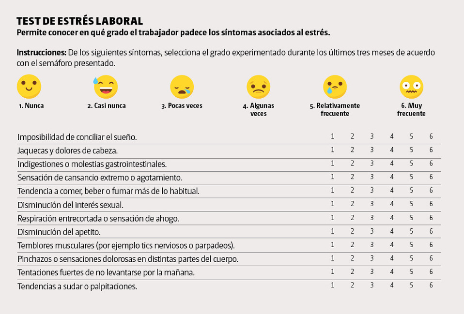

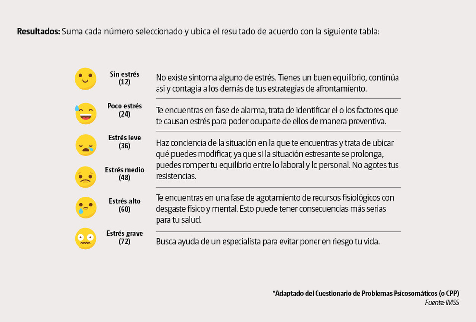

### Base de Datos

```r
library(readr)
library(dplyr)
DF<-read_csv("Base_DatosFINAL.csv")
```

### ¿Cuál es la edad de los encuestados?

```r
summary(DF$Edad)
```

```
##    Min. 1st Qu.  Median    Mean 3rd Qu.    Max.
##   17.00   18.00   19.00   19.18   20.00   24.00
```

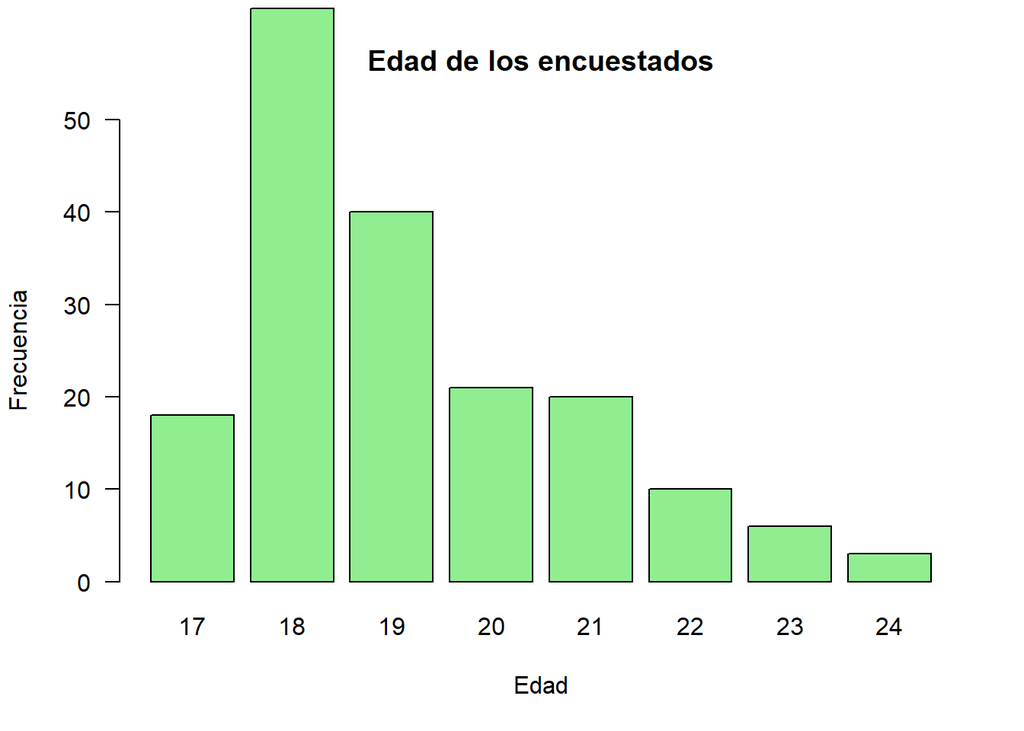

```r
barplot(table(DF$Edad),xlab="Edad", ylab="Frecuencia",main="Edad de los encuestados", col="lightgreen",las=1,cex.names=1,ylim=c(0,50))
```

### ¿Cuánto tiempo les demora a los estudiantes de UTEC llegar a la universidad desde su lugar de residencia?

```r
summary(DF$Tiempo_Transporte/2)
```

```
##    Min. 1st Qu.  Median    Mean 3rd Qu.    Max.
##    2.00   25.00   45.00   51.81   75.00  150.00
```

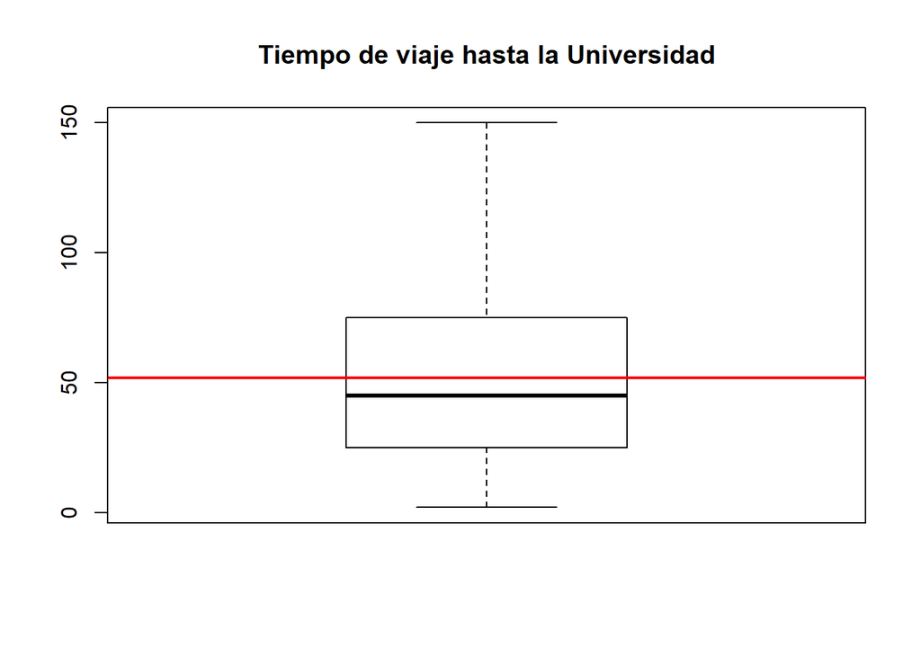

```r
boxplot(DF$Tiempo_Transporte/2)
abline(mean(DF$Tiempo_Transporte/2),0,col="red",title("Tiempo de viaje hasta la Universidad"), lwd=2)
```

### ¿Cómo califican los estudiantes la experiencia de transporte?

```r
summary(DF$Calificacion)
```

```
##    Min. 1st Qu.  Median    Mean 3rd Qu.    Max.
##   1.000   5.000   7.000   6.572   8.000  10.000
```

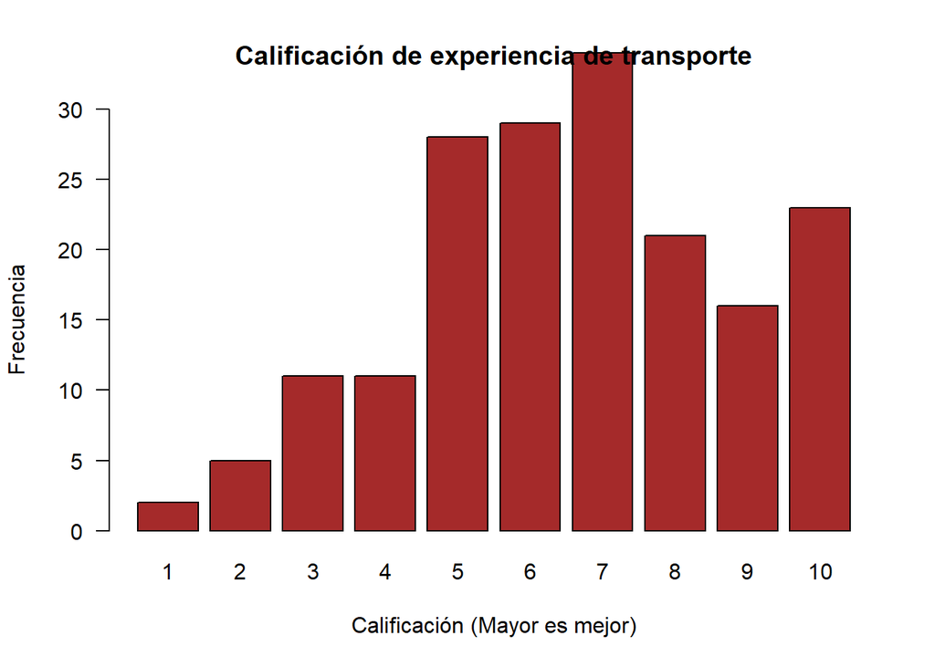

```r
barplot(table(DF$Calificacion), xlab="Calificación (Mayor es mejor)", ylab="Frecuencia", las=1,cex.names=1,ylim=c(0,30), col="brown", main = "Calificación de experiencia de transporte")
```

### ¿Cuál es el medio de transporte más utilizado?

```r
medios <- read_csv("Transporte.csv") #medios es igual a la suma de M1, M2, M3 Y M4 en DF
```

**Porcentajes de los medios de transporte (%):**

```r
round(table(medios$Actividad)/length(medios$Actividad)*100,2)
```

```
##
##           A pie           Carro     Micro/combi Otro transporte
##            4.79           15.97           21.73           57.51
```

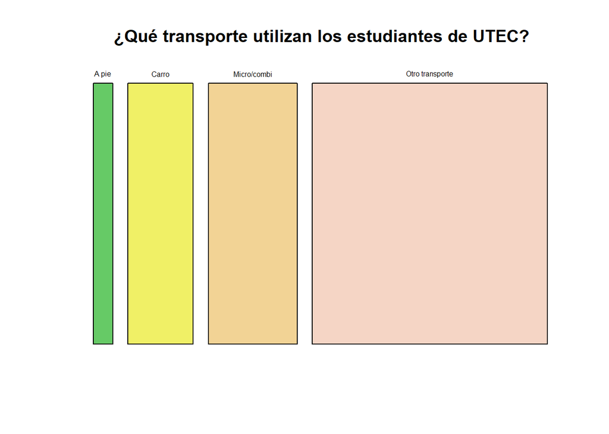

```r
mosaicplot(table(medios$Actividad),
 main="¿Qué transporte utilizan los estudiantes de UTEC?",
 col=terrain.colors(5, alpha = .6), las=1,cex.axis = 0.5)
```

### ¿Qué tan estresados se sentían los alumnos de UTEC el ciclo 2019-2?

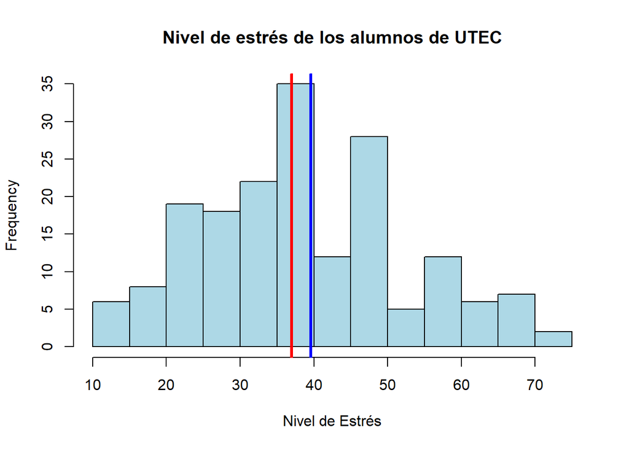

```r
hist(DF$Estres,main="Nivel de estrés de los alumnos de UTEC",
     col="lightblue",breaks=15,xlab="Nivel de Estrés")
abline(v=median(DF$Estres),col="red", lwd=3)
abline(v=mean(DF$Estres),col="blue", lwd=3)
```

**Porcentaje de Niveles de Estrés en Alumnos (%):**

**Sin Estrés:**

```r
round(length(DF$Estres[DF$Estres==12])/length(DF$Estres)*100,2)
```

```
## [1] 0.56
```

**Poco Estrés:**

```r
round(length(DF$Estres[DF$Estres<25 & DF$Estres>12])/length(DF$Estres)*100,2)
```

```
## [1] 16.11
```

**Estrés leve:**

```r
round(length(DF$Estres[DF$Estres<37 & DF$Estres>24])/length(DF$Estres)*100,2)
```

```
## [1] 30
```

**Estrés medio:**

```r
round(length(DF$Estres[DF$Estres<49 & DF$Estres>36])/length(DF$Estres)*100,2)
```

```
## [1] 29.44
```

**Estrés alto:**

```r
round(length(DF$Estres[DF$Estres<61 & DF$Estres>48])/length(DF$Estres)*100,2)
```

```
## [1] 15.56
```

**Estrés grave:**

```r
round(length(DF$Estres[DF$Estres<73 & DF$Estres>60])/length(DF$Estres)*100,2)
```

```
## [1] 8.33
```

### ¿Qué actividades realizarían los alumnos con el tiempo que utilizan para transportarse?

```r
actividades <- read_csv("Actividad.csv") #medios es igual a la suma de A1, A2, A3, A4 y A5 en DF
```

**Porcentajes de las Actividades que realizarían los estudiantes(%):**

```r
round(table(actividades$Actividad)/length(medios$Actividad)*100,2)
```

```
##
##         Dormir       Estudiar Familia/amigos         Idioma           Otra
##          36.42          36.42           9.27           2.88          27.16
##    Videojuegos
##          16.29
```

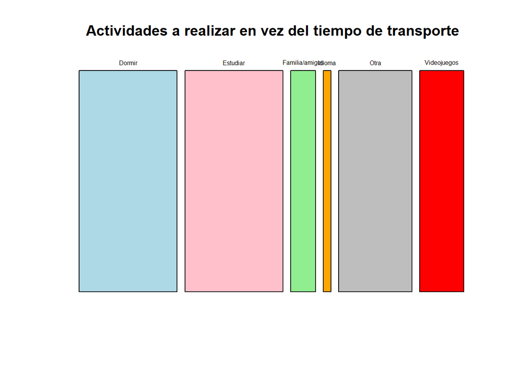

```r
mosaicplot(table(actividades$Actividad),
 main="Actividades a realizar en vez del tiempo de transporte",
  col = c("lightblue","pink","lightgreen", "orange", "gray","red"), las=1,cex.axis = 0.5)
```

### ¿Que porcentaje de alumnos tienen días con 3 horas o menos de clases?¿Para que porcentaje de alumnos el tiempo de transporte diario es mayor que el número de horas de clase en estos días (3 horas)?

```r
perdida_tiempo<-DF[DF$Dias_Inutiles>0,]
```

**Porcentaje de alumnos que tienen días de clases con 3 horas o menos:**

```r
round(length(perdida_tiempo$Dias_Inutiles)/length(DF$Dias_Inutiles)*100,2)
```

```
## [1] 79.44
```

**Diagrama de barras sobre la cantidad de días a la semana con 3 horas o menos de clase de los alumnos:**

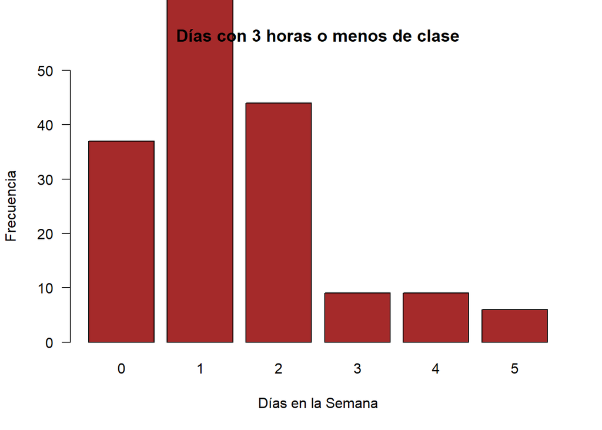

```r
barplot(table(DF$Dias_Inutiles),xlab="Días en la Semana", ylab="Frecuencia",main="Días con 3 horas o menos de clase", col="brown",las=1,cex.names=1,ylim=c(0,50))
```

```r
perdida_total<-perdida_tiempo[perdida_tiempo$Tiempo_Transporte>180,]
```

**Porcentaje de alumnos que tienen días con 3 horas o menos de clases y un tiempo de transporte mayor a 3 horas:**

```r
round(length(perdida_total$Dias_Inutiles)/length(DF$Dias_Inutiles)*100,2)
```

```
## [1] 11.11
```

**Diagrama de barras sobre la cantidad de días con 3 horas o menos de clase semanales de los alumnos cuyo tiempo de transporte es mayor a 3 horas:**

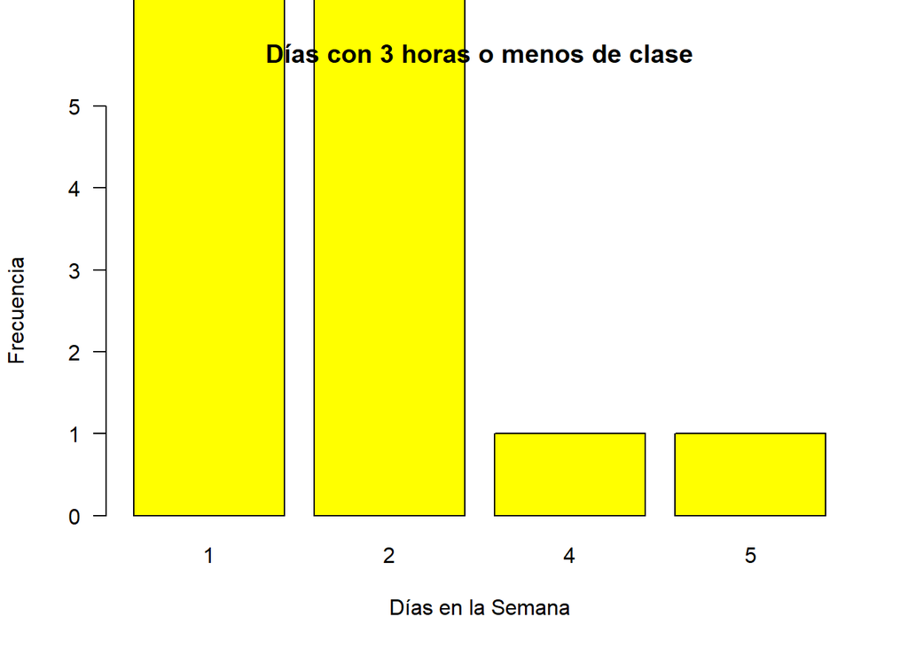

```r
barplot(table(perdida_total$Dias_Inutiles),xlab="Días en la Semana", ylab="Frecuencia",main="Días con 3 horas o menos de clase", col="yellow",las=1,cex.names=1,ylim=c(0,5))
```

### ¿Existe una relación entre la edad y el tiempo que pasan en el transporte?

Se puede ver que los estudiantes de 17 años llegan hasta mas 25 horas semanales , en cambio los que ya tienen 21, se aglomeran mas en el rango entre 0 a 8 horas semanales.

**HIPÓTESIS:**  
Conforme la edad va aumentando,el de transporte semanal de los alumnos disminuye.

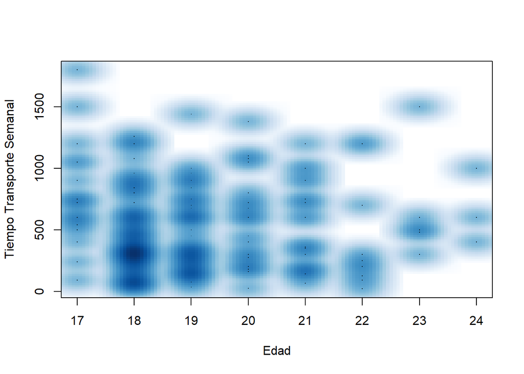

```r
smoothScatter(DF$Edad,DF$Transporte_Semanal,ylab= "Tiempo Transporte Semanal",xlab="Edad")
```

### ¿Existe una relación entre el número de horas que duermen los estudiantes y el nivel de estrés que presentan?

**HIPÓTESIS:** Los estudiantes que tienen un nivel de estrés mayor, duermen menos horas diariamente.

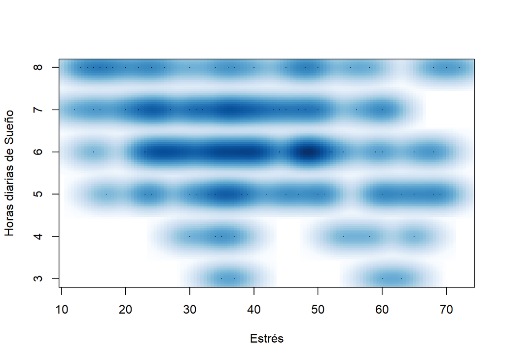

```r
smoothScatter(DF$Estres,DF$Tiempo_Dormir,ylab= "Horas diarias de Sueño",xlab="Estrés")
```

```r
DF%>% filter()%>%group_by(Tiempo_Dormir)%>%summarise(Media_Tiempo=mean(Transporte_Semanal),Mediana_Tiempo=median(Transporte_Semanal))->dormir_transporte
dormir_transporte
```

| Tiempo_Dormir | Media_Tiempo | Mediana_Tiempo |
| --- | --- | --- |
| 3 | 630.0000 | 300 |
| 4 | 564.2857 | 600 |
| 5 | 586.8750 | 600 |
| 6 | 597.8571 | 600 |
| 7 | 463.4043 | 360 |
| 8 | 314.2308 | 300 |
| NA | 1440.0000 | 1440 |

### ¿Existe alguna relación entre el tiempo que pasan en el transporte y la cantidad de cursos desaprobados del estudiante?

**ANÁLISIS:** No es posible hallar patrones debido a que hay muy poca información sobre alumnos desaprobados.

**HIPÓTESIS:** No existe una relación clara entre estas variables.

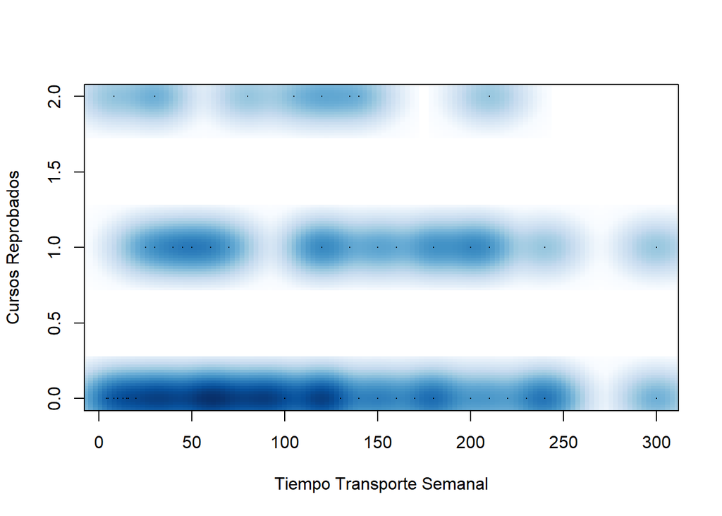

```r
smoothScatter(DF$Tiempo_Transporte,DF$NroReprobados,ylab= "Cursos Reprobados",xlab="Tiempo Transporte Semanal")
```

```r
DF%>% filter()%>%group_by(NroReprobados)%>%summarise(Media_Tiempo=mean(Transporte_Semanal),Mediana_Tiempo=median(Transporte_Semanal))->reprobados_transporte
reprobados_transporte
```

| NroReprobados | Media_Tiempo | Mediana_Tiempo |
| --- | --- | --- |
| 0 | 496.7910 | 400 |
| 1 | 611.4286 | 600 |
| 2 | 543.5000 | 615 |
| NA | 900.0000 | 900 |

### ¿Existe alguna relación entre el tiempo que pasan en el transporte y el promedio del estudiante en el ciclo 2019-2?

**ANÁLISIS:** En la gráfica se puede notar que un gran porcentaje de estudiantes tiene un promedio ponderado entre 14 y 16. No obstante, no es posible determinar una relación entre esta variable y la del tiempo de transporte.

**HIPÓTESIS:** El tiempo de transporte no influye en el promedio ponderado del alumno.

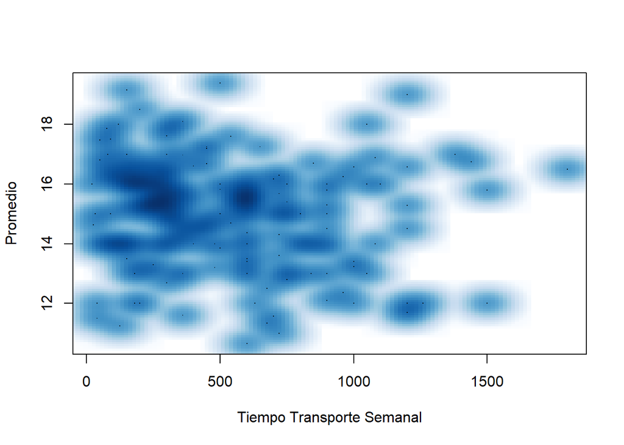

```r
smoothScatter(DF$Transporte_Semanal,DF$Promedio,ylab= "Promedio",xlab="Tiempo Transporte Semanal")
```

### ¿Existe alguna relación entre el grado de mérito del estudiante y las horas que se transporta semanalmente?

**ANÁLISIS:** De esta tabla se puede observar que al estar en un percentil mayor, la mediana de tiempo de transporte semanal es menor.

**HIPÓTESIS:** Mientras menos horas de transporte semanal tiene un alumno, hay una mayor probabilidad de poder encontrarse en un percentil mayor respecto a su carrera.

```r
DF%>% filter()%>%group_by(Percentil)%>%summarise(Mediana_Tiempo=median(Transporte_Semanal))->percentil_transporte
percentil_transporte
```

| Percentil | Mediana_Tiempo |
| --- | --- |
| Decimo superior | 300 |
| Menos de tercio superior | 615 |
| Quinto superior | 380 |
| Tercio superior | 450 |

### ¿Existe alguna relación entre las horas que se transportan semanalmente y las horas que duermen diariamente los estudiantes?

**HIPÓTESIS:** Mientras mayor sea la cantidad de tiempo de transporte semanal, menor será las horas que duermen los alumnos diariamente.

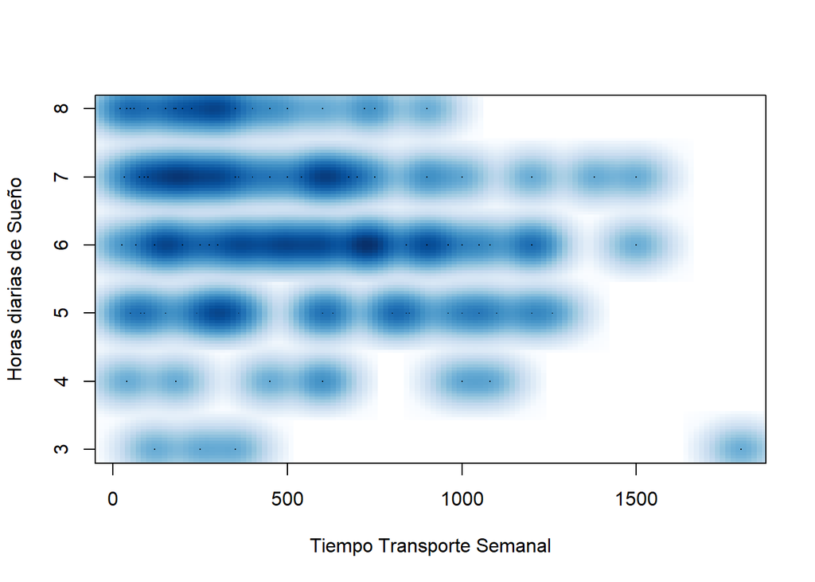

```r
smoothScatter(DF$Transporte_Semanal,DF$Tiempo_Dormir,ylab= "Horas diarias de Sueño",xlab="Tiempo Transporte Semanal")
```

```r
DF%>% filter()%>%group_by(Tiempo_Dormir)%>%summarise(Mediana_Tiempo=median(Transporte_Semanal))->Dormir_transporte
Dormir_transporte
```

| Tiempo_Dormir | Mediana_Tiempo |
| --- | --- |
| 3 | 300 |
| 4 | 600 |
| 5 | 600 |
| 6 | 600 |
| 7 | 360 |
| 8 | 300 |
| NA | 1440 |

### ¿Existe alguna relación las horas semanales de transporte con la calificación que le pone el alumno al transporte?

**ANÁLISIS:** En este gráfico podemos observar que hay una mayor concentración de calificaciones altas en los alumnos que tienen un menor tiempo de transporte, mientras que las calificaciones bajas están más dispersas.

**HIPÓTESIS:** Si un alumno pasa menos tiempo transportándose, tendrá una mejor experiencia y por consiguiente, le podrá una calificación más alta que alguien que tiene una gran cantidad de horas de transporte.

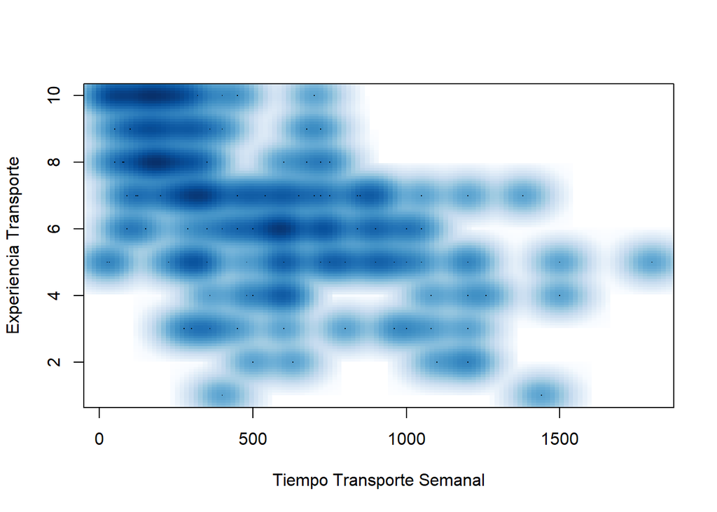

```r
smoothScatter(DF$Transporte_Semanal,DF$Calificacion,ylab= "Experiencia Transporte",xlab="Tiempo Transporte Semanal")
```

```r
DF[DF$Transporte_Semanal==max(DF$Transporte_Semanal),]
```

| X1 | Edad | Cursos | Promedio | NroReprobados | Percentil | Distrito | Calificacion | Tiempo_Transporte | Dias_Clase | Horas_Clase | Tiempo_Dormir | Dias_Inutiles | Horas_Estudio | Horas_Extracurricular | Estres | M1 | M2 | M3 | M4 | A1 | A2 | A3 | A4 | A5 | Transporte_Semanal |
| --- | --- | --- | --- | --- | --- | --- | --- | --- | --- | --- | --- | --- | --- | --- | --- | --- | --- | --- | --- | --- | --- | --- | --- | --- | --- |
| 70 | 17 | 5 | 16.5 | 0 | Decimo superior | Callao (Provincia Constitucional) | 5 | 300 | 6 | 20 | 3 | 2 | 5 o mas | 2 | 60 | Metropolitano / Corredor rojo | Combi / micro | NA | NA | Estudiar | Dormir | Deporte o alguna actividad fisica | Pasar tiempo con familia o amigos | NA | 1800 |

### Bibliografía:

- https://gestion.pe/tendencias/lima-ciudades-peor-trafico-269483-noticia/
- https://amp.milenio.com/especiales/estres-cronico-como-identificarlo